# **Problem Statement**

## Business Context

Renewable energy sources play an increasingly important role in the global energy mix, as the effort to reduce the environmental impact of energy production increases.

Out of all the renewable energy alternatives, wind energy is one of the most developed technologies worldwide. The U.S Department of Energy has put together a guide to achieving operational efficiency using predictive maintenance practices.

Predictive maintenance uses sensor information and analysis methods to measure and predict degradation and future component capability. The idea behind predictive maintenance is that failure patterns are predictable and if component failure can be predicted accurately and the component is replaced before it fails, the costs of operation and maintenance will be much lower.

The sensors fitted across different machines involved in the process of energy generation collect data related to various environmental factors (temperature, humidity, wind speed, etc.) and additional features related to various parts of the wind turbine (gearbox, tower, blades, break, etc.).

## Objective

“ReneWind” is a company working on improving the machinery/processes involved in the production of wind energy using machine learning and has collected data of generator failure of wind turbines using sensors. They have shared a ciphered version of the data, as the data collected through sensors is confidential (the type of data collected varies with companies). Data has 40 predictors, 20000 observations in the training set and 5000 in the test set.

The objective is to build various classification models, tune them, and find the best one that will help identify failures so that the generators could be repaired before failing/breaking to reduce the overall maintenance cost. The nature of predictions made by the classification model will translate as follows:

- True positives (TP) are failures correctly predicted by the model. These will result in repairing costs.
- False negatives (FN) are real failures where there is no detection by the model. These will result in replacement costs.
- False positives (FP) are detections where there is no failure. These will result in inspection costs.

It is given that the cost of repairing a generator is much less than the cost of replacing it, and the cost of inspection is less than the cost of repair.

“1” in the target variables should be considered as “failure” and “0” represents “No failure”.

## Data Description

The data provided is a transformed version of the original data which was collected using sensors.

- Train.csv - To be used for training and tuning of models.
- Test.csv - To be used only for testing the performance of the final best model.

Both the datasets consist of 40 predictor variables and 1 target variable.

# **Installing and Importing the necessary libraries**

```python
# Installing the libraries with the specified version
%pip install --no-deps tensorflow==2.15.1 scikit-learn==1.6.1 matplotlib==3.10.0 seaborn==0.13.2 numpy==1.26.4 pandas==2.2.2 -q --user --no-warn-script-location
```

**Note**:

- After running the above cell, kindly restart the runtime (for Google Colab) or notebook kernel (for Jupyter Notebook), and run all cells sequentially from the next cell.
- On executing the above line of code, you might see a warning regarding package dependencies. This error message can be ignored as the above code ensures that all necessary libraries and their dependencies are maintained to successfully execute the code in **this notebook**.

```python
# Library for data manipulation and analysis.
import pandas as pd
# Fundamental package for scientific computing.
import numpy as np
#splitting datasets into training and testing sets.
from sklearn.model_selection import train_test_split
#Imports tools for data preprocessing including label encoding, one-hot encoding, and standard scaling
from sklearn.preprocessing import LabelEncoder, OneHotEncoder,StandardScaler
#Imports a class for imputing missing values in datasets.
from sklearn.impute import SimpleImputer
#Imports the Matplotlib library for creating visualizations.
from sklearn.metrics import confusion_matrix
import matplotlib.pyplot as plt
# Imports the Seaborn library for statistical data visualization.
import seaborn as sns
# Time related functions.
import time
#Imports functions for evaluating the performance of machine learning models
from sklearn.metrics import confusion_matrix, f1_score,accuracy_score, recall_score, precision_score, classification_report
#Imports metrics from
from sklearn import metrics

#Imports the tensorflow,keras and layers.
import tensorflow
import tensorflow as tf
from tensorflow.keras.models import Sequential
from tensorflow.keras.layers import Dense
from tensorflow.keras.layers import Dense, Input, Dropout,BatchNormalization
from tensorflow.keras import backend

# to suppress unnecessary warnings
import warnings
warnings.filterwarnings("ignore")
```

```
2026-05-24 20:55:01.372815: I tensorflow/core/platform/cpu_feature_guard.cc:182] This TensorFlow binary is optimized to use available CPU instructions in performance-critical operations.
To enable the following instructions: AVX2 FMA, in other operations, rebuild TensorFlow with the appropriate compiler flags.
```

# **Loading the Data**

```python
# uncomment and run the following lines for Google Colab
# from google.colab import drive
# drive.mount('/content/drive')
```

```python
df = pd.read_csv("train.csv")    # import the training data
df_test = pd.read_csv("test.csv")    # import the test data
```

# **Data Overview**

The initial steps to get an overview of any dataset is to:

- observe the first few rows of the dataset, to check whether the dataset has been loaded properly or not
- get information about the number of rows and columns in the dataset
- find out the data types of the columns to ensure that data is stored in the preferred format and the value of each property is as expected.
- check the statistical summary of the dataset to get an overview of the numerical columns of the data

## Checking the shape of the dataset

```python
# Checking the number of rows and columns in the training data
df.shape # print the shape of the train data
```

```
(20000, 41)
```

```python
# let's create a copy of the training data
data_train = df.copy()
```

```python
# Checking the number of rows and columns in the test data
df_test.shape # print the shape of the test data
```

```
(5000, 41)
```

```python
# let's create a copy of the testing  data
data_test = df_test.copy()
```

## Displaying the first few rows of the dataset

```python
# let's view the first 5 rows of the data
data_train.head() # view the first five rows of the train data
```

|  | V1 | V2 | V3 | V4 | V5 | V6 | V7 | V8 | V9 | V10 | ... | V32 | V33 | V34 | V35 | V36 | V37 | V38 | V39 | V40 | Target |
| --- | --- | --- | --- | --- | --- | --- | --- | --- | --- | --- | --- | --- | --- | --- | --- | --- | --- | --- | --- | --- | --- |
| 0 | -4.464606 | -4.679129 | 3.101546 | 0.506130 | -0.221083 | -2.032511 | -2.910870 | 0.050714 | -1.522351 | 3.761892 | ... | 3.059700 | -1.690440 | 2.846296 | 2.235198 | 6.667486 | 0.443809 | -2.369169 | 2.950578 | -3.480324 | 0 |
| 1 | 3.365912 | 3.653381 | 0.909671 | -1.367528 | 0.332016 | 2.358938 | 0.732600 | -4.332135 | 0.565695 | -0.101080 | ... | -1.795474 | 3.032780 | -2.467514 | 1.894599 | -2.297780 | -1.731048 | 5.908837 | -0.386345 | 0.616242 | 0 |
| 2 | -3.831843 | -5.824444 | 0.634031 | -2.418815 | -1.773827 | 1.016824 | -2.098941 | -3.173204 | -2.081860 | 5.392621 | ... | -0.257101 | 0.803550 | 4.086219 | 2.292138 | 5.360850 | 0.351993 | 2.940021 | 3.839160 | -4.309402 | 0 |
| 3 | 1.618098 | 1.888342 | 7.046143 | -1.147285 | 0.083080 | -1.529780 | 0.207309 | -2.493629 | 0.344926 | 2.118578 | ... | -3.584425 | -2.577474 | 1.363769 | 0.622714 | 5.550100 | -1.526796 | 0.138853 | 3.101430 | -1.277378 | 0 |
| 4 | -0.111440 | 3.872488 | -3.758361 | -2.982897 | 3.792714 | 0.544960 | 0.205433 | 4.848994 | -1.854920 | -6.220023 | ... | 8.265896 | 6.629213 | -10.068689 | 1.222987 | -3.229763 | 1.686909 | -2.163896 | -3.644622 | 6.510338 | 0 |

5 rows × 41 columns

```python
#viewing first 5 rows of the test data
data_test.head() # view the first five rows of the test data
```

|  | V1 | V2 | V3 | V4 | V5 | V6 | V7 | V8 | V9 | V10 | ... | V32 | V33 | V34 | V35 | V36 | V37 | V38 | V39 | V40 | Target |
| --- | --- | --- | --- | --- | --- | --- | --- | --- | --- | --- | --- | --- | --- | --- | --- | --- | --- | --- | --- | --- | --- |
| 0 | -0.613489 | -3.819640 | 2.202302 | 1.300420 | -1.184929 | -4.495964 | -1.835817 | 4.722989 | 1.206140 | -0.341909 | ... | 2.291204 | -5.411388 | 0.870073 | 0.574479 | 4.157191 | 1.428093 | -10.511342 | 0.454664 | -1.448363 | 0 |
| 1 | 0.389608 | -0.512341 | 0.527053 | -2.576776 | -1.016766 | 2.235112 | -0.441301 | -4.405744 | -0.332869 | 1.966794 | ... | -2.474936 | 2.493582 | 0.315165 | 2.059288 | 0.683859 | -0.485452 | 5.128350 | 1.720744 | -1.488235 | 0 |
| 2 | -0.874861 | -0.640632 | 4.084202 | -1.590454 | 0.525855 | -1.957592 | -0.695367 | 1.347309 | -1.732348 | 0.466500 | ... | -1.318888 | -2.997464 | 0.459664 | 0.619774 | 5.631504 | 1.323512 | -1.752154 | 1.808302 | 1.675748 | 0 |
| 3 | 0.238384 | 1.458607 | 4.014528 | 2.534478 | 1.196987 | -3.117330 | -0.924035 | 0.269493 | 1.322436 | 0.702345 | ... | 3.517918 | -3.074085 | -0.284220 | 0.954576 | 3.029331 | -1.367198 | -3.412140 | 0.906000 | -2.450889 | 0 |
| 4 | 5.828225 | 2.768260 | -1.234530 | 2.809264 | -1.641648 | -1.406698 | 0.568643 | 0.965043 | 1.918379 | -2.774855 | ... | 1.773841 | -1.501573 | -2.226702 | 4.776830 | -6.559698 | -0.805551 | -0.276007 | -3.858207 | -0.537694 | 0 |

5 rows × 41 columns

```python
# let's check the data types of the columns in the dataset
data_train.dtypes # view the data types of the columns in the train data
```

```
V1        float64
V2        float64
V3        float64
V4        float64
V5        float64
V6        float64
V7        float64
V8        float64
V9        float64
V10       float64
V11       float64
V12       float64
V13       float64
V14       float64
V15       float64
V16       float64
V17       float64
V18       float64
V19       float64
V20       float64
V21       float64
V22       float64
V23       float64
V24       float64
V25       float64
V26       float64
V27       float64
V28       float64
V29       float64
V30       float64
V31       float64
V32       float64
V33       float64
V34       float64
V35       float64
V36       float64
V37       float64
V38       float64
V39       float64
V40       float64
Target      int64
dtype: object
```

- Converting Target column to float

```python
data_train['Target'] = data_train['Target'].astype(float)
```

Now checking for test data

```python
data_test.dtypes # view the data types of the columns in the test data
```

```
V1        float64
V2        float64
V3        float64
V4        float64
V5        float64
V6        float64
V7        float64
V8        float64
V9        float64
V10       float64
V11       float64
V12       float64
V13       float64
V14       float64
V15       float64
V16       float64
V17       float64
V18       float64
V19       float64
V20       float64
V21       float64
V22       float64
V23       float64
V24       float64
V25       float64
V26       float64
V27       float64
V28       float64
V29       float64
V30       float64
V31       float64
V32       float64
V33       float64
V34       float64
V35       float64
V36       float64
V37       float64
V38       float64
V39       float64
V40       float64
Target      int64
dtype: object
```

Converting Target to float

```python
data_test['Target'] = data_test['Target'].astype(float)
```

```python
# let's check for duplicate values in the data
data_train.duplicated().sum() # check for duplicate values in the train data
```

```
0
```

## Checking for missing values

```python
# let's check for missing values in the data
data_train.isnull().sum()
```

```
V1        18
V2        18
V3         0
V4         0
V5         0
V6         0
V7         0
V8         0
V9         0
V10        0
V11        0
V12        0
V13        0
V14        0
V15        0
V16        0
V17        0
V18        0
V19        0
V20        0
V21        0
V22        0
V23        0
V24        0
V25        0
V26        0
V27        0
V28        0
V29        0
V30        0
V31        0
V32        0
V33        0
V34        0
V35        0
V36        0
V37        0
V38        0
V39        0
V40        0
Target     0
dtype: int64
```

```python
# let's check for missing values in the test data
data_test.isnull().sum() #
```

```
V1        5
V2        6
V3        0
V4        0
V5        0
V6        0
V7        0
V8        0
V9        0
V10       0
V11       0
V12       0
V13       0
V14       0
V15       0
V16       0
V17       0
V18       0
V19       0
V20       0
V21       0
V22       0
V23       0
V24       0
V25       0
V26       0
V27       0
V28       0
V29       0
V30       0
V31       0
V32       0
V33       0
V34       0
V35       0
V36       0
V37       0
V38       0
V39       0
V40       0
Target    0
dtype: int64
```

## Statistical summary of the dataset

```python
# let's view the statistical summary of the numerical columns in the data
data_train.describe() # view the statistical summary of the numerical columns in the train data
```

|  | V1 | V2 | V3 | V4 | V5 | V6 | V7 | V8 | V9 | V10 | ... | V32 | V33 | V34 | V35 | V36 | V37 | V38 | V39 | V40 | Target |
| --- | --- | --- | --- | --- | --- | --- | --- | --- | --- | --- | --- | --- | --- | --- | --- | --- | --- | --- | --- | --- | --- |
| count | 19982.000000 | 19982.000000 | 20000.000000 | 20000.000000 | 20000.000000 | 20000.000000 | 20000.000000 | 20000.000000 | 20000.000000 | 20000.000000 | ... | 20000.000000 | 20000.000000 | 20000.000000 | 20000.000000 | 20000.000000 | 20000.000000 | 20000.000000 | 20000.000000 | 20000.000000 | 20000.000000 |
| mean | -0.271996 | 0.440430 | 2.484699 | -0.083152 | -0.053752 | -0.995443 | -0.879325 | -0.548195 | -0.016808 | -0.012998 | ... | 0.303799 | 0.049825 | -0.462702 | 2.229620 | 1.514809 | 0.011316 | -0.344025 | 0.890653 | -0.875630 | 0.055500 |
| std | 3.441625 | 3.150784 | 3.388963 | 3.431595 | 2.104801 | 2.040970 | 1.761626 | 3.295756 | 2.160568 | 2.193201 | ... | 5.500400 | 3.575285 | 3.183841 | 2.937102 | 3.800860 | 1.788165 | 3.948147 | 1.753054 | 3.012155 | 0.228959 |
| min | -11.876451 | -12.319951 | -10.708139 | -15.082052 | -8.603361 | -10.227147 | -7.949681 | -15.657561 | -8.596313 | -9.853957 | ... | -19.876502 | -16.898353 | -17.985094 | -15.349803 | -14.833178 | -5.478350 | -17.375002 | -6.438880 | -11.023935 | 0.000000 |
| 25% | -2.737146 | -1.640674 | 0.206860 | -2.347660 | -1.535607 | -2.347238 | -2.030926 | -2.642665 | -1.494973 | -1.411212 | ... | -3.420469 | -2.242857 | -2.136984 | 0.336191 | -0.943809 | -1.255819 | -2.987638 | -0.272250 | -2.940193 | 0.000000 |
| 50% | -0.747917 | 0.471536 | 2.255786 | -0.135241 | -0.101952 | -1.000515 | -0.917179 | -0.389085 | -0.067597 | 0.100973 | ... | 0.052073 | -0.066249 | -0.255008 | 2.098633 | 1.566526 | -0.128435 | -0.316849 | 0.919261 | -0.920806 | 0.000000 |
| 75% | 1.840112 | 2.543967 | 4.566165 | 2.130615 | 1.340480 | 0.380330 | 0.223695 | 1.722965 | 1.409203 | 1.477045 | ... | 3.761722 | 2.255134 | 1.436935 | 4.064358 | 3.983939 | 1.175533 | 2.279399 | 2.057540 | 1.119897 | 0.000000 |
| max | 15.493002 | 13.089269 | 17.090919 | 13.236381 | 8.133797 | 6.975847 | 8.006091 | 11.679495 | 8.137580 | 8.108472 | ... | 23.633187 | 16.692486 | 14.358213 | 15.291065 | 19.329576 | 7.467006 | 15.289923 | 7.759877 | 10.654265 | 1.000000 |

8 rows × 41 columns

## Checking for duplicate values

# **Exploratory Data Analysis**

## Univariate analysis

```python
# function to plot a boxplot and a histogram along the same scale.

def histogram_boxplot(data, feature, figsize=(12, 7), kde=False, bins=None):
    """
    Boxplot and histogram combined

    data: dataframe
    feature: dataframe column
    figsize: size of figure (default (12,7))
    kde: whether to the show density curve (default False)
    bins: number of bins for histogram (default None)
    """
    f2, (ax_box2, ax_hist2) = plt.subplots(
        nrows=2,  # Number of rows of the subplot grid= 2
        sharex=True,  # x-axis will be shared among all subplots
        gridspec_kw={"height_ratios": (0.25, 0.75)},
        figsize=figsize,
    )  # creating the 2 subplots
    ax_box2.set_title(feature)
    sns.boxplot(
        data=data, x=feature, ax=ax_box2, showmeans=True, color="violet"
    )  # boxplot will be created and a star will indicate the mean value of the column
    sns.histplot(
        data=data, x=feature, kde=kde, ax=ax_hist2, bins=bins, palette="winter"
    ) if bins else sns.histplot(
        data=data, x=feature, kde=kde, ax=ax_hist2
    )  # For histogram
    ax_hist2.axvline(
        data[feature].mean(), color="green", linestyle="--"
    )  # Add mean to the histogram
    ax_hist2.axvline(
        data[feature].median(), color="black", linestyle="-"
    )  # Add median to the histogram
```

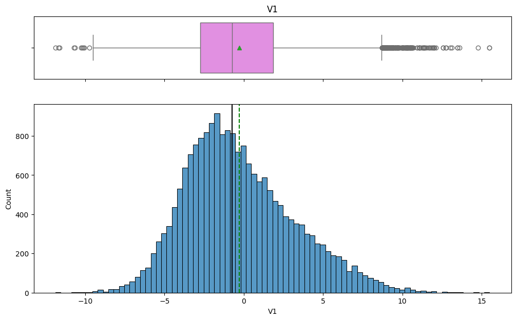

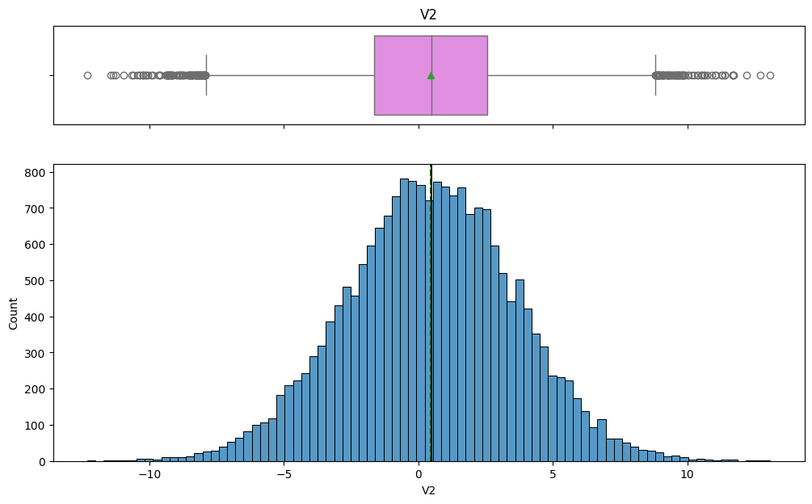

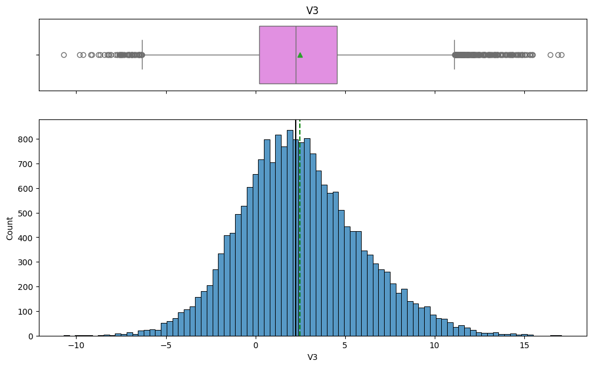

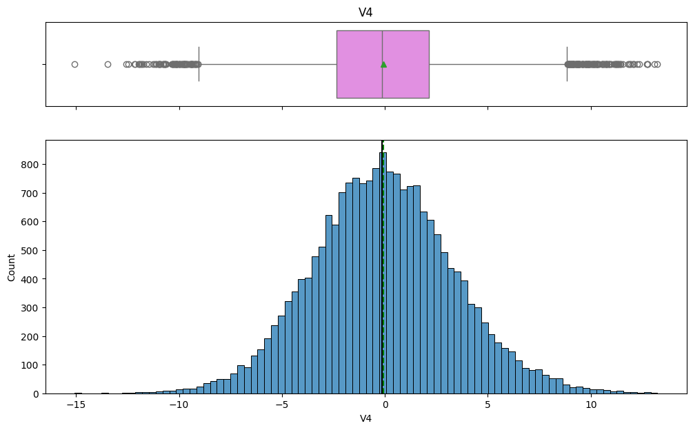

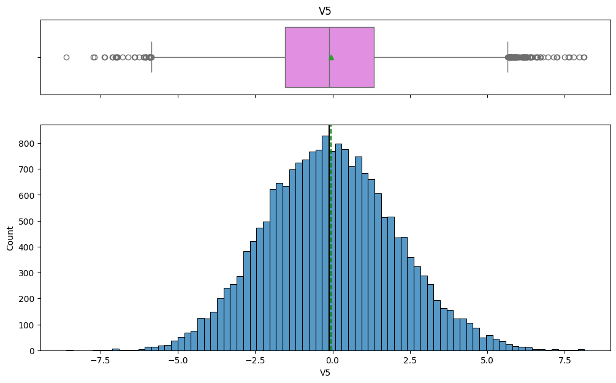

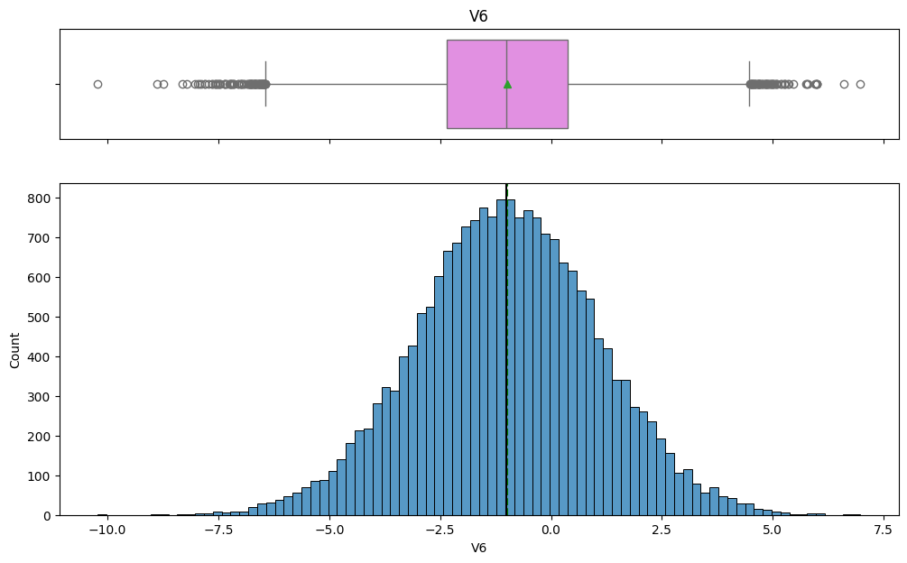

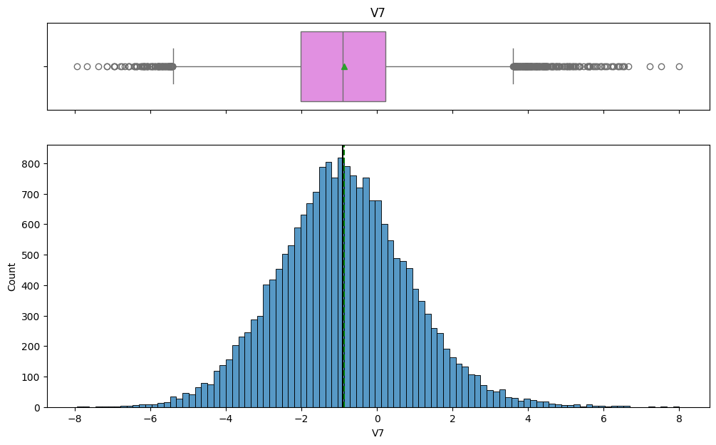

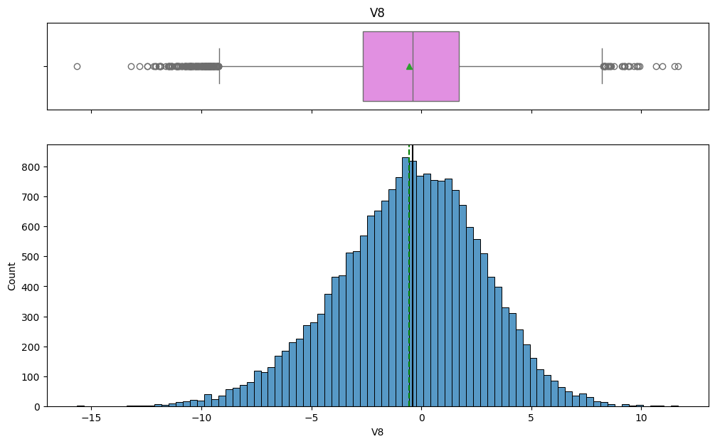

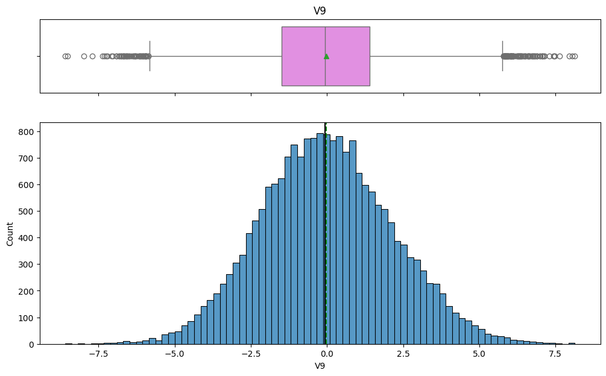

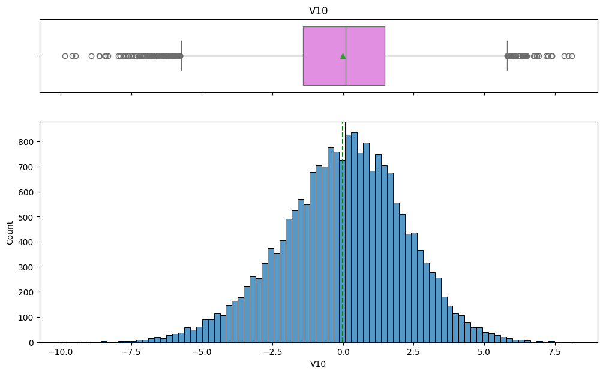

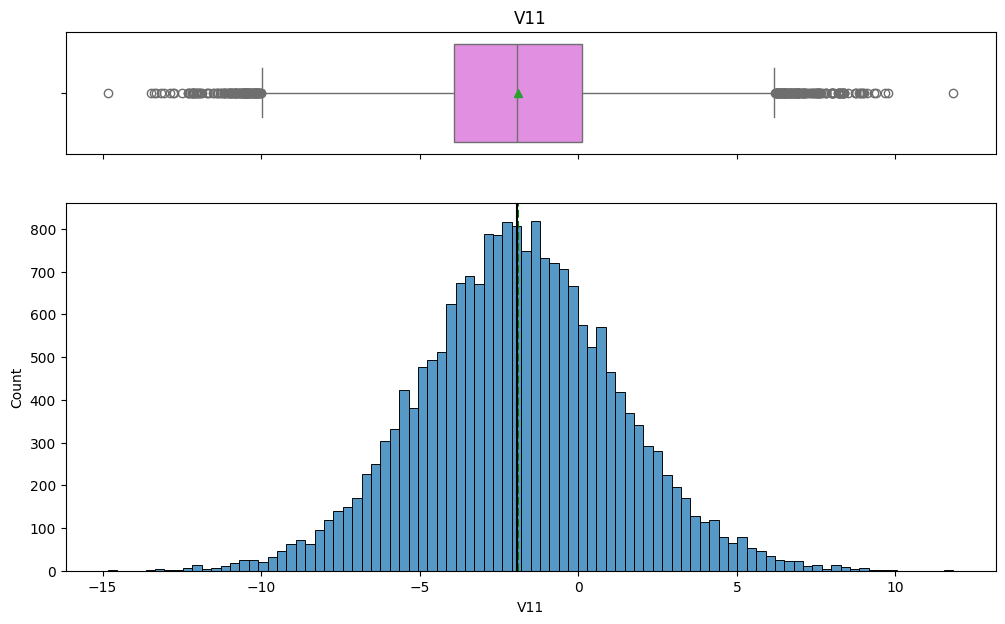

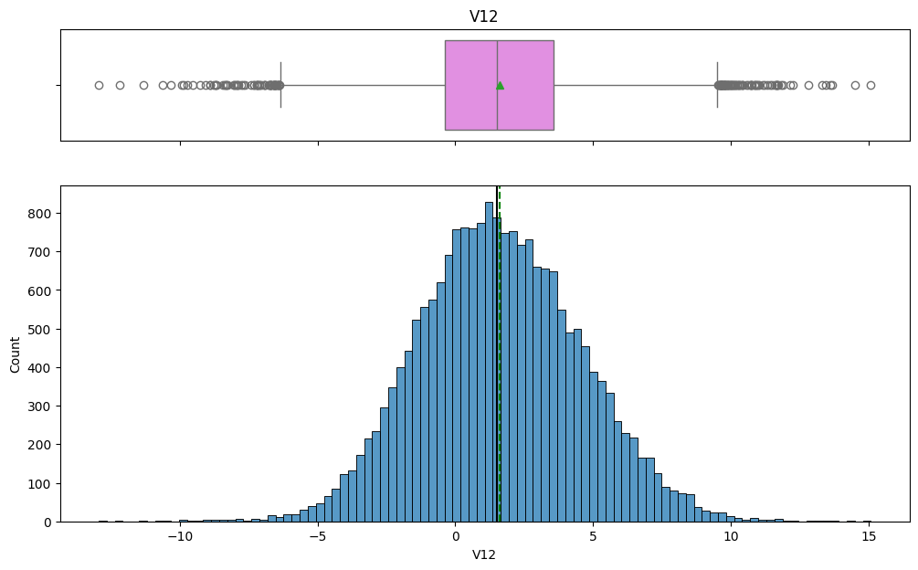

[29 more figures not shown]

```python
for feature in data_train.columns:
    histogram_boxplot(data_train, feature, figsize=(12, 7), kde=False, bins=None)
```

#### Univariate Observations:

**Distributions**

- Most features (V1–V40) show approximately symmetric, bell-shaped distributions — means and medians are close across the majority of variables.
- **V3** and **V35** are shifted noticeably above zero (means of 2.48 and 2.23), unlike most other features which are centered near 0.
- **V6** and **V7** are consistently negative-shifted (means of -1.00 and -0.88).

**Outliers**

- Nearly all features show outliers on both tails in the boxplots — extreme values extend well beyond the whiskers.
- **V32** has the widest spread (std = 5.50, range ≈ -19.9 to +23.6) and the most pronounced outliers.
- **V38** and **V36** also show notably wide ranges with outlier-heavy tails.
- These outliers likely represent abnormal sensor readings and **should not be removed**, as they may correspond to actual failure conditions.

### Checking the distrubution of Target variable

```python
# For train data
data_train["Target"].value_counts(1)
```

```
Target
0.0    0.9445
1.0    0.0555
Name: proportion, dtype: float64
```

```python
# For test data
df_test["Target"].value_counts(1) # Print the value counts of the target column in the test data
```

```
Target
0    0.9436
1    0.0564
Name: proportion, dtype: float64
```

**Target Variable**

- The target is heavily imbalanced: ~94.4% class 0 (no failure) vs. ~5.5% class 1 (failure).
- The distribution is almost entirely concentrated at 0, making this a rare-event detection problem.

## Bivariate Analysis

### Correlation Check

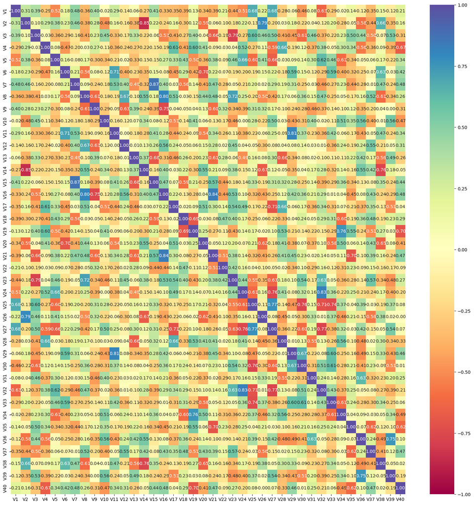

```python
cols_list = data_train.select_dtypes(include=np.number).columns.tolist()
cols_list.remove("Target")

plt.figure(figsize=(20, 20))
sns.heatmap(
    data_train[cols_list].corr(), annot=True, vmin=-1, vmax=1, fmt=".2f", cmap="Spectral"
)
plt.show()
```

### Bivariate Observations:

**Feature-to-Feature Correlations (Heatmap)**

- There are **119 feature pairs with |r| > 0.5**, indicating widespread multicollinearity across the 40 predictors.
- The strongest correlations are:
  - V7 & V15: **+0.868** (strong positive)
  - V2 & V14: **-0.854** (strong negative)
  - V16 & V21: **+0.837** (strong positive)
  - V24 & V32: **+0.825** (strong positive)
  - V11 & V29: **+0.811** (strong positive)
- Both positive and negative high correlations exist, suggesting some sensor readings move together while others are inversely related.
- The high degree of inter-feature correlation suggests **redundancy** in the feature set — several variables likely capture overlapping information from related components or sensors.

**Feature-to-Target Correlations**

**Conclusions**

- The widespread multicollinearity may cause issues for linear models but is handled well by neural networks, which learn non-linear feature interactions automatically.
- Since no single predictor strongly separates failure from non-failure, the classification task is genuinely complex and benefits from a deep learning approach.
- Highly correlated feature pairs (e.g., V7 & V15, V2 & V14) could be candidates for dimensionality reduction, though for neural networks this is generally less critical than for tree-based or linear models.

# **Data Preprocessing**

## Data Preparation for Modeling

```python
# Dividing train data into X and y
X = data_train.drop(columns = ["Target"] , axis=1) # remove the column named 'Target'
y = data_train["Target"] # select the column named 'Target'
```

**Since we already have a separate test set, we don't need to divide data into train, valiation and test**

```python
# Splitting data into training and validation set:

X_train, X_val, y_train, y_val = train_test_split(
    X, y, test_size=0.2, random_state=1, stratify=y # define the test size
)
```

```python
# Checking the number of rows and columns in the X_train data
X_train.shape
```

```
(16000, 40)
```

```python
# Checking the number of rows and columns in the X_val data
X_val.shape
```

```
(4000, 40)
```

```python
# Dividing test data into X_test and y_test
X_test = data_test.drop(columns = ['Target'] , axis= 1) # remove the column named 'Target'
y_test = data_test["Target"] # select the column named 'Target'
```

```python
# Checking the number of rows and columns in the X_test data
X_test.shape
```

```
(5000, 40)
```

## Missing Value Imputation

- There were few missing values in V1 and V2, we will impute them using the median.
- And to avoid data leakage we will impute missing values after splitting train data into train and validation sets.

```python
imputer = SimpleImputer(strategy="median")
```

```python
scaler = StandardScaler()
# Fit and scale the train data
X_train = pd.DataFrame(scaler.fit_transform(X_train), columns=X_train.columns)
# Fit and scale the validation and test data
X_val   = pd.DataFrame(scaler.transform(X_val),       columns=X_train.columns)
X_test  = pd.DataFrame(scaler.transform(X_test),      columns=X_train.columns)

# Fit and transform the train data
X_train = pd.DataFrame(imputer.fit_transform(X_train), columns=X_train.columns)

# Transform the validation data
X_val = pd.DataFrame(imputer.transform(X_val), columns=X_train.columns)    # impute missing values in the validation set while accounting for data leakage

# Transform the test data
X_test = pd.DataFrame(imputer.transform(X_test), columns=X_train.columns)    # impute missing values in the test set while accounting for data leakage
```

```python
# Checking that no column has missing values in train or test sets
print(X_train.isna().sum())
print("-" * 30)
print(X_val.isna().sum())
print("-" * 30)
print(X_test.isna().sum())
```

```
V1     0
V2     0
V3     0
V4     0
V5     0
V6     0
V7     0
V8     0
V9     0
V10    0
V11    0
V12    0
V13    0
V14    0
V15    0
V16    0
V17    0
V18    0
V19    0
V20    0
V21    0
V22    0
V23    0
V24    0
V25    0
V26    0
V27    0
V28    0
V29    0
V30    0
V31    0
V32    0
V33    0
V34    0
V35    0
V36    0
V37    0
V38    0
V39    0
V40    0
```

[output cut: 70 more lines]

```
V27    0
V28    0
V29    0
V30    0
V31    0
V32    0
V33    0
V34    0
V35    0
V36    0
V37    0
V38    0
V39    0
V40    0
dtype: int64
```

```python
y_train = np.array(y_train) # convert y_train to a numpy array
y_val = np.array(y_val) # convert y_val to a numpy array
y_test = np.array(y_test) # convert y_test to a numpy array
```

# **Model Building**

## Model Evaluation Criterion

**Primary metric: Recall**

The costliest outcome is a **False Negative** — a real failure that goes undetected, resulting in full generator replacement. Since replacement costs far exceed repair costs, we want to minimize missed failures above all else. Recall (= TP / TP + FN) directly measures this.

**Secondary metric: F1 Score**

Recall alone could be gamed by predicting failure for everything. False Positives (unnecessary inspections) still have a cost, so F1 score — which balances precision and recall — is used to ensure the model remains practical.

**Why not accuracy?**

The dataset is heavily imbalanced (only ~5.5% failures). A model that predicts "no failure" every time would achieve ~94.5% accuracy while being completely useless. Accuracy is therefore misleading here.

**Summary of cost priority from the problem statement:**

| Prediction | Actual | Outcome | Cost |
| --- | --- | --- | --- |
| 1 | 1 | TP | Repair (medium) |
| 0 | 1 | FN | Replacement (highest) |
| 1 | 0 | FP | Inspection (lowest) |
| 0 | 0 | TN | None |

The model should be tuned to prioritize **high recall** while keeping F1 score acceptable.

## Utility Functions

```python
def plot(history, name):
    """
    Function to plot loss/accuracy

    history: an object which stores the metrics and losses.
    name: can be one of Loss or Accuracy
    """
    fig, ax = plt.subplots() #Creating a subplot with figure and axes.
    plt.plot(history.history[name]) #Plotting the train accuracy or train loss
    plt.plot(history.history['val_'+name]) #Plotting the validation accuracy or validation loss

    plt.title('Model ' + name.capitalize()) #Defining the title of the plot.
    plt.ylabel(name.capitalize()) #Capitalizing the first letter.
    plt.xlabel('Epoch') #Defining the label for the x-axis.
    fig.legend(['Train', 'Validation'], loc="outside right upper") #Defining the legend, loc controls the position of the legend.
```

```python
# defining a function to compute different metrics to check performance of a classification model built using statsmodels
def model_performance_classification(
    model, predictors, target, threshold=0.5
):
    """
    Function to compute different metrics to check classification model performance

    model: classifier
    predictors: independent variables
    target: dependent variable
    threshold: threshold for classifying the observation as class 1
    """

    # checking which probabilities are greater than threshold
    pred = model.predict(predictors) > threshold
    # pred_temp = model.predict(predictors) > threshold
    # # rounding off the above values to get classes
    # pred = np.round(pred_temp)

    acc = accuracy_score(target, pred)  # to compute Accuracy
    recall = recall_score(target, pred, average='macro')  # to compute Recall
    precision = precision_score(target, pred, average='macro')  # to compute Precision
    f1 = f1_score(target, pred, average='macro')  # to compute F1-score

    # creating a dataframe of metrics
    df_perf = pd.DataFrame(
        {"Accuracy": acc, "Recall": recall, "Precision": precision, "F1 Score": f1,}, index = [0]
    )

    return df_perf
```

## Initial Model Building (Model 0)

- Let's start with a neural network consisting of
  - just one hidden layer
  - activation function of ReLU
  - SGD as the optimizer

```python
# defining the batch size and # epochs upfront as we'll be using the same values for all models
epochs = 50    # Complete the code to enter the number of epochs to be used in all models
batch_size = 32    # Complete the code to enter the batch size to be used in all models
```

```python
# clears the current Keras session, resetting all layers and models previously created, freeing up memory and resources.
tf.keras.backend.clear_session()
```

```python
#Initializing the neural network
model_0 = Sequential()
model_0.add(Dense(64, activation="relu", input_dim=X_train.shape[1])) # Complete the code to define the number of neurons and the activation function
model_0.add(Dense(1, activation="sigmoid")) # Complete the code to define the number of neurons in the output layer
```

```python
model_0.summary()
```

```
Model: "sequential"
```

```
┏━━━━━━━━━━━━━━━━━━━━━━━━━━━━━━━━━┳━━━━━━━━━━━━━━━━━━━━━━━━┳━━━━━━━━━━━━━━━┓
┃ Layer (type)                    ┃ Output Shape           ┃       Param # ┃
┡━━━━━━━━━━━━━━━━━━━━━━━━━━━━━━━━━╇━━━━━━━━━━━━━━━━━━━━━━━━╇━━━━━━━━━━━━━━━┩
│ dense (Dense)                   │ (None, 64)             │         2,624 │
├─────────────────────────────────┼────────────────────────┼───────────────┤
│ dense_1 (Dense)                 │ (None, 1)              │            65 │
└─────────────────────────────────┴────────────────────────┴───────────────┘
```

```
 Total params: 2,689 (10.50 KB)
```

```
 Trainable params: 2,689 (10.50 KB)
```

```
 Non-trainable params: 0 (0.00 B)
```

```python
optimizer = tf.keras.optimizers.SGD()   # defining SGD as the optimizer to be used
# model_0.compile(loss='binary_crossentropy', optimizer=optimizer, metrics = ['accuracy']) ## Uncomment this line in case the metric of choice is Accuracy
# model_0.compile(loss='binary_crossentropy', optimizer=optimizer, metrics = ['Precision']) ## Uncomment this line in case the metric of choice is Precision
model_0.compile(loss='binary_crossentropy', optimizer=optimizer, metrics = ['Recall']) ## Uncomment this line in case the metric of choice is Recall
# model_0.compile(loss='binary_crossentropy', optimizer=optimizer, metrics = ['f1_score']) ## Uncomment this line in case the metric of choice is F1 Score
```

```python
start = time.time()
history = model_0.fit(X_train, y_train, validation_data=(X_val,y_val) , batch_size=batch_size, epochs=epochs)
end=time.time()
```

```
500/500 ━━━━━━━━━━━━━━━━━━━━ 1s 2ms/step - Recall: 0.1430 - loss: 0.2243 - val_Recall: 0.3153 - val_loss: 0.1505
500/500 ━━━━━━━━━━━━━━━━━━━━ 1s 1ms/step - Recall: 0.3547 - loss: 0.1405 - val_Recall: 0.4685 - val_loss: 0.1277
500/500 ━━━━━━━━━━━━━━━━━━━━ 1s 1ms/step - Recall: 0.4505 - loss: 0.1233 - val_Recall: 0.5180 - val_loss: 0.1164
500/500 ━━━━━━━━━━━━━━━━━━━━ 1s 1ms/step - Recall: 0.5056 - loss: 0.1131 - val_Recall: 0.5405 - val_loss: 0.1088
500/500 ━━━━━━━━━━━━━━━━━━━━ 1s 1ms/step - Recall: 0.5349 - loss: 0.1058 - val_Recall: 0.5991 - val_loss: 0.1033
500/500 ━━━━━━━━━━━━━━━━━━━━ 1s 1ms/step - Recall: 0.5721 - loss: 0.0999 - val_Recall: 0.6081 - val_loss: 0.0984
500/500 ━━━━━━━━━━━━━━━━━━━━ 1s 1ms/step - Recall: 0.5935 - loss: 0.0949 - val_Recall: 0.6306 - val_loss: 0.0942
500/500 ━━━━━━━━━━━━━━━━━━━━ 1s 1ms/step - Recall: 0.6137 - loss: 0.0906 - val_Recall: 0.6486 - val_loss: 0.0906
500/500 ━━━━━━━━━━━━━━━━━━━━ 1s 1ms/step - Recall: 0.6385 - loss: 0.0869 - val_Recall: 0.6712 - val_loss: 0.0876
500/500 ━━━━━━━━━━━━━━━━━━━━ 1s 1ms/step - Recall: 0.6565 - loss: 0.0836 - val_Recall: 0.6847 - val_loss: 0.0849
500/500 ━━━━━━━━━━━━━━━━━━━━ 1s 1ms/step - Recall: 0.6723 - loss: 0.0807 - val_Recall: 0.6892 - val_loss: 0.0826
500/500 ━━━━━━━━━━━━━━━━━━━━ 1s 1ms/step - Recall: 0.6836 - loss: 0.0781 - val_Recall: 0.7072 - val_loss: 0.0806
500/500 ━━━━━━━━━━━━━━━━━━━━ 1s 1ms/step - Recall: 0.6971 - loss: 0.0759 - val_Recall: 0.7117 - val_loss: 0.0788
500/500 ━━━━━━━━━━━━━━━━━━━━ 1s 1ms/step - Recall: 0.7128 - loss: 0.0739 - val_Recall: 0.7117 - val_loss: 0.0772
500/500 ━━━━━━━━━━━━━━━━━━━━ 1s 2ms/step - Recall: 0.7173 - loss: 0.0721 - val_Recall: 0.7162 - val_loss: 0.0759
500/500 ━━━━━━━━━━━━━━━━━━━━ 1s 1ms/step - Recall: 0.7297 - loss: 0.0704 - val_Recall: 0.7207 - val_loss: 0.0747
500/500 ━━━━━━━━━━━━━━━━━━━━ 1s 1ms/step - Recall: 0.7365 - loss: 0.0690 - val_Recall: 0.7252 - val_loss: 0.0736
500/500 ━━━━━━━━━━━━━━━━━━━━ 1s 1ms/step - Recall: 0.7410 - loss: 0.0676 - val_Recall: 0.7477 - val_loss: 0.0726
500/500 ━━━━━━━━━━━━━━━━━━━━ 1s 1ms/step - Recall: 0.7511 - loss: 0.0663 - val_Recall: 0.7387 - val_loss: 0.0719
500/500 ━━━━━━━━━━━━━━━━━━━━ 1s 1ms/step - Recall: 0.7489 - loss: 0.0652 - val_Recall: 0.7568 - val_loss: 0.0708
500/500 ━━━━━━━━━━━━━━━━━━━━ 1s 1ms/step - Recall: 0.7568 - loss: 0.0642 - val_Recall: 0.7523 - val_loss: 0.0700
500/500 ━━━━━━━━━━━━━━━━━━━━ 1s 1ms/step - Recall: 0.7579 - loss: 0.0631 - val_Recall: 0.7793 - val_loss: 0.0696
500/500 ━━━━━━━━━━━━━━━━━━━━ 1s 1ms/step - Recall: 0.7646 - loss: 0.0623 - val_Recall: 0.7883 - val_loss: 0.0688
500/500 ━━━━━━━━━━━━━━━━━━━━ 1s 1ms/step - Recall: 0.7669 - loss: 0.0614 - val_Recall: 0.7838 - val_loss: 0.0682
500/500 ━━━━━━━━━━━━━━━━━━━━ 1s 1ms/step - Recall: 0.7748 - loss: 0.0607 - val_Recall: 0.7838 - val_loss: 0.0677
500/500 ━━━━━━━━━━━━━━━━━━━━ 1s 1ms/step - Recall: 0.7782 - loss: 0.0599 - val_Recall: 0.7838 - val_loss: 0.0673
500/500 ━━━━━━━━━━━━━━━━━━━━ 1s 1ms/step - Recall: 0.7827 - loss: 0.0593 - val_Recall: 0.7838 - val_loss: 0.0669
500/500 ━━━━━━━━━━━━━━━━━━━━ 1s 1ms/step - Recall: 0.7917 - loss: 0.0586 - val_Recall: 0.7883 - val_loss: 0.0664
500/500 ━━━━━━━━━━━━━━━━━━━━ 1s 1ms/step - Recall: 0.7939 - loss: 0.0580 - val_Recall: 0.7883 - val_loss: 0.0660
500/500 ━━━━━━━━━━━━━━━━━━━━ 1s 1ms/step - Recall: 0.7984 - loss: 0.0574 - val_Recall: 0.7838 - val_loss: 0.0655
500/500 ━━━━━━━━━━━━━━━━━━━━ 1s 1ms/step - Recall: 0.7973 - loss: 0.0569 - val_Recall: 0.7838 - val_loss: 0.0654
500/500 ━━━━━━━━━━━━━━━━━━━━ 1s 1ms/step - Recall: 0.8007 - loss: 0.0564 - val_Recall: 0.7883 - val_loss: 0.0651
500/500 ━━━━━━━━━━━━━━━━━━━━ 1s 1ms/step - Recall: 0.8018 - loss: 0.0559 - val_Recall: 0.7973 - val_loss: 0.0649
500/500 ━━━━━━━━━━━━━━━━━━━━ 1s 1ms/step - Recall: 0.8097 - loss: 0.0555 - val_Recall: 0.7928 - val_loss: 0.0645
500/500 ━━━━━━━━━━━━━━━━━━━━ 1s 1ms/step - Recall: 0.8108 - loss: 0.0551 - val_Recall: 0.8018 - val_loss: 0.0643
500/500 ━━━━━━━━━━━━━━━━━━━━ 1s 1ms/step - Recall: 0.8198 - loss: 0.0547 - val_Recall: 0.8018 - val_loss: 0.0641
500/500 ━━━━━━━━━━━━━━━━━━━━ 1s 1ms/step - Recall: 0.8153 - loss: 0.0543 - val_Recall: 0.8108 - val_loss: 0.0638
500/500 ━━━━━━━━━━━━━━━━━━━━ 1s 1ms/step - Recall: 0.8209 - loss: 0.0539 - val_Recall: 0.7973 - val_loss: 0.0636
500/500 ━━━━━━━━━━━━━━━━━━━━ 1s 1ms/step - Recall: 0.8176 - loss: 0.0537 - val_Recall: 0.8063 - val_loss: 0.0634
500/500 ━━━━━━━━━━━━━━━━━━━━ 1s 1ms/step - Recall: 0.8232 - loss: 0.0533 - val_Recall: 0.8018 - val_loss: 0.0632
500/500 ━━━━━━━━━━━━━━━━━━━━ 1s 1ms/step - Recall: 0.8176 - loss: 0.0530 - val_Recall: 0.8063 - val_loss: 0.0630
500/500 ━━━━━━━━━━━━━━━━━━━━ 1s 1ms/step - Recall: 0.8221 - loss: 0.0527 - val_Recall: 0.8018 - val_loss: 0.0629
500/500 ━━━━━━━━━━━━━━━━━━━━ 1s 1ms/step - Recall: 0.8232 - loss: 0.0524 - val_Recall: 0.7973 - val_loss: 0.0626
500/500 ━━━━━━━━━━━━━━━━━━━━ 1s 1ms/step - Recall: 0.8232 - loss: 0.0522 - val_Recall: 0.8108 - val_loss: 0.0625
500/500 ━━━━━━━━━━━━━━━━━━━━ 1s 1ms/step - Recall: 0.8277 - loss: 0.0519 - val_Recall: 0.8153 - val_loss: 0.0626
500/500 ━━━━━━━━━━━━━━━━━━━━ 1s 1ms/step - Recall: 0.8232 - loss: 0.0517 - val_Recall: 0.8153 - val_loss: 0.0624
500/500 ━━━━━━━━━━━━━━━━━━━━ 1s 1ms/step - Recall: 0.8255 - loss: 0.0515 - val_Recall: 0.8108 - val_loss: 0.0622
500/500 ━━━━━━━━━━━━━━━━━━━━ 1s 1ms/step - Recall: 0.8277 - loss: 0.0513 - val_Recall: 0.8063 - val_loss: 0.0621
500/500 ━━━━━━━━━━━━━━━━━━━━ 1s 1ms/step - Recall: 0.8288 - loss: 0.0510 - val_Recall: 0.8153 - val_loss: 0.0620
500/500 ━━━━━━━━━━━━━━━━━━━━ 1s 1ms/step - Recall: 0.8277 - loss: 0.0509 - val_Recall: 0.8153 - val_loss: 0.0618
```

```python
print("Time taken in seconds ",end-start)
```

```
Time taken in seconds  34.73987698554993
```

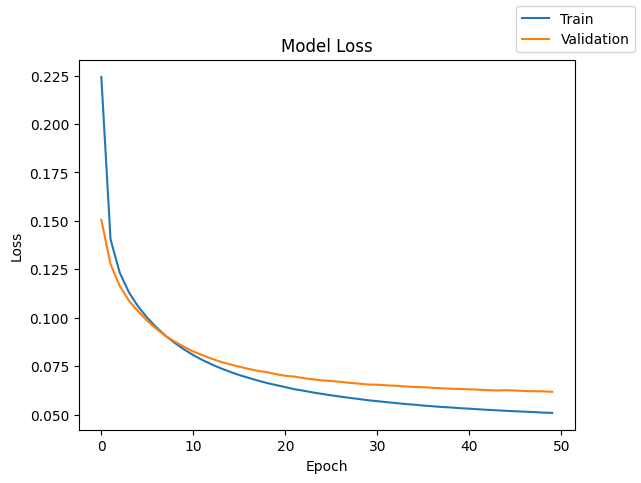

```python
plot(history,'loss')
```

```python
model_0_train_perf = model_performance_classification(model_0, X_train, y_train)
model_0_train_perf
```

```
500/500 ━━━━━━━━━━━━━━━━━━━━ 0s 745us/step
```

|  | Accuracy | Recall | Precision | F1 Score |
| --- | --- | --- | --- | --- |
| 0 | 0.990187 | 0.915839 | 0.989761 | 0.949403 |

```python
model_0_val_perf = model_performance_classification(model_0,X_val,y_val)
model_0_val_perf
```

```
125/125 ━━━━━━━━━━━━━━━━━━━━ 0s 820us/step
```

|  | Accuracy | Recall | Precision | F1 Score |
| --- | --- | --- | --- | --- |
| 0 | 0.98875 | 0.907128 | 0.983816 | 0.941754 |

Let's check the classification reports.

```python
y_train_pred_0 = model_0.predict(X_train)
y_val_pred_0 = model_0.predict(X_val)
```

```
500/500 ━━━━━━━━━━━━━━━━━━━━ 0s 683us/step
125/125 ━━━━━━━━━━━━━━━━━━━━ 0s 805us/step
```

```python
print("Classification Report - Train data Model_0",end="\n\n")
cr_train_model_0 = classification_report(y_train,y_train_pred_0>0.5)
print(cr_train_model_0)
```

```
Classification Report - Train data Model_0

              precision    recall  f1-score   support

         0.0       0.99      1.00      0.99     15112
         1.0       0.99      0.83      0.90       888

    accuracy                           0.99     16000
   macro avg       0.99      0.92      0.95     16000
weighted avg       0.99      0.99      0.99     16000
```

```python
print("Classification Report - Validation data Model_0",end="\n\n")
cr_val_model_0 = classification_report(y_val,y_val_pred_0>0.5)
print(cr_val_model_0)
```

```
Classification Report - Validation data Model_0

              precision    recall  f1-score   support

         0.0       0.99      1.00      0.99      3778
         1.0       0.98      0.82      0.89       222

    accuracy                           0.99      4000
   macro avg       0.98      0.91      0.94      4000
weighted avg       0.99      0.99      0.99      4000
```

### Model 0 — Observations and Insights

**Architecture**

- Single hidden layer with 64 ReLU units, sigmoid output, SGD optimizer
- 2,689 trainable parameters — the simplest possible baseline

**Final Model Performance**

[output not shown]

**Classification Report — Failure class (Class 1) only:**

| Set | Precision | Recall | F1 | Support |
| --- | --- | --- | --- | --- |
| Train | 0.99 | 0.83 | 0.90 | 888 |
| Validation | 0.98 | 0.82 | 0.89 | 222 |

- The model identifies **83% of training failures** and **82% of validation failures**
- Non-failure class (Class 0) achieves near-perfect recall (1.00) on both sets — the model almost never falsely flags a healthy generator
- Train and validation metrics are very close, confirming the model generalizes well with **no overfitting**

**Business Context**

- 82% recall on Class 1 means **~18% of real failures go undetected**, resulting in costly generator replacements
- For this problem, recall on Class 1 should be as close to 1.0 as possible
- Model 0 establishes a solid baseline; subsequent models should target higher Class 1 recall through deeper architectures, alternative optimizers (e.g. Adam), class weighting, or adjusted classification thresholds

# **Model Performance Improvement**

## Model 1

- Let's try adding another layer to see if we can improve our model's performance.

```python
# clears the current Keras session, resetting all layers and models previously created, freeing up memory and resources.
tf.keras.backend.clear_session()
```

```python
#Initializing the neural network
model_1 = Sequential()
model_1.add(Dense(64,activation="relu",input_dim=X_train.shape[1])) # Complete the code to define the number of neurons and activation function
model_1.add(Dense(32,activation="relu")) # Complete the code to define the number of neurons and activation function
model_1.add(Dense(1,activation="sigmoid")) # Complete the code to define the number of neurons in the output layer
```

```python
model_1.summary()
```

```
Model: "sequential"
```

```
┏━━━━━━━━━━━━━━━━━━━━━━━━━━━━━━━━━┳━━━━━━━━━━━━━━━━━━━━━━━━┳━━━━━━━━━━━━━━━┓
┃ Layer (type)                    ┃ Output Shape           ┃       Param # ┃
┡━━━━━━━━━━━━━━━━━━━━━━━━━━━━━━━━━╇━━━━━━━━━━━━━━━━━━━━━━━━╇━━━━━━━━━━━━━━━┩
│ dense (Dense)                   │ (None, 64)             │         2,624 │
├─────────────────────────────────┼────────────────────────┼───────────────┤
│ dense_1 (Dense)                 │ (None, 32)             │         2,080 │
├─────────────────────────────────┼────────────────────────┼───────────────┤
│ dense_2 (Dense)                 │ (None, 1)              │            33 │
└─────────────────────────────────┴────────────────────────┴───────────────┘
```

```
 Total params: 4,737 (18.50 KB)
```

```
 Trainable params: 4,737 (18.50 KB)
```

```
 Non-trainable params: 0 (0.00 B)
```

```python
optimizer = tf.keras.optimizers.SGD()   # defining SGD as the optimizer to be used
# model_1.compile(loss='binary_crossentropy', optimizer=optimizer, metrics = ['accuracy']) ## Uncomment this line in case the metric of choice is Accuracy
# model_1.compile(loss='binary_crossentropy', optimizer=optimizer, metrics = ['Precision']) ## Uncomment this line in case the metric of choice is Precision
model_1.compile(loss='binary_crossentropy', optimizer=optimizer, metrics = ['Recall']) ## Uncomment this line in case the metric of choice is Recall
# model_1.compile(loss='binary_crossentropy', optimizer=optimizer, metrics = ['f1_score']) ## Uncomment this line in case the metric of choice is F1 Score
```

```python
start = time.time()
history = model_1.fit(X_train, y_train, validation_data=(X_val,y_val) , batch_size=batch_size, epochs=epochs)
end=time.time()
```

```
500/500 ━━━━━━━━━━━━━━━━━━━━ 1s 2ms/step - Recall: 0.0011 - loss: 0.2271 - val_Recall: 0.0090 - val_loss: 0.1683
500/500 ━━━━━━━━━━━━━━━━━━━━ 1s 1ms/step - Recall: 0.1622 - loss: 0.1485 - val_Recall: 0.3108 - val_loss: 0.1319
500/500 ━━━━━━━━━━━━━━━━━━━━ 1s 1ms/step - Recall: 0.3930 - loss: 0.1202 - val_Recall: 0.4910 - val_loss: 0.1124
500/500 ━━━━━━━━━━━━━━━━━━━━ 1s 1ms/step - Recall: 0.5484 - loss: 0.1038 - val_Recall: 0.5586 - val_loss: 0.1010
500/500 ━━━━━━━━━━━━━━━━━━━━ 1s 1ms/step - Recall: 0.6239 - loss: 0.0932 - val_Recall: 0.6532 - val_loss: 0.0925
500/500 ━━━━━━━━━━━━━━━━━━━━ 1s 1ms/step - Recall: 0.6802 - loss: 0.0854 - val_Recall: 0.7207 - val_loss: 0.0868
500/500 ━━━━━━━━━━━━━━━━━━━━ 1s 1ms/step - Recall: 0.7140 - loss: 0.0796 - val_Recall: 0.7297 - val_loss: 0.0817
500/500 ━━━━━━━━━━━━━━━━━━━━ 1s 1ms/step - Recall: 0.7365 - loss: 0.0749 - val_Recall: 0.7297 - val_loss: 0.0782
500/500 ━━━━━━━━━━━━━━━━━━━━ 1s 1ms/step - Recall: 0.7534 - loss: 0.0710 - val_Recall: 0.7387 - val_loss: 0.0750
500/500 ━━━━━━━━━━━━━━━━━━━━ 1s 1ms/step - Recall: 0.7680 - loss: 0.0680 - val_Recall: 0.7568 - val_loss: 0.0726
500/500 ━━━━━━━━━━━━━━━━━━━━ 1s 1ms/step - Recall: 0.7804 - loss: 0.0654 - val_Recall: 0.7477 - val_loss: 0.0705
500/500 ━━━━━━━━━━━━━━━━━━━━ 1s 1ms/step - Recall: 0.7917 - loss: 0.0631 - val_Recall: 0.7568 - val_loss: 0.0689
500/500 ━━━━━━━━━━━━━━━━━━━━ 1s 1ms/step - Recall: 0.7950 - loss: 0.0611 - val_Recall: 0.7658 - val_loss: 0.0676
500/500 ━━━━━━━━━━━━━━━━━━━━ 1s 1ms/step - Recall: 0.7995 - loss: 0.0595 - val_Recall: 0.7703 - val_loss: 0.0663
500/500 ━━━━━━━━━━━━━━━━━━━━ 1s 1ms/step - Recall: 0.8041 - loss: 0.0580 - val_Recall: 0.7883 - val_loss: 0.0649
500/500 ━━━━━━━━━━━━━━━━━━━━ 1s 1ms/step - Recall: 0.8131 - loss: 0.0567 - val_Recall: 0.7883 - val_loss: 0.0640
500/500 ━━━━━━━━━━━━━━━━━━━━ 1s 1ms/step - Recall: 0.8176 - loss: 0.0554 - val_Recall: 0.7883 - val_loss: 0.0628
500/500 ━━━━━━━━━━━━━━━━━━━━ 1s 1ms/step - Recall: 0.8232 - loss: 0.0544 - val_Recall: 0.7883 - val_loss: 0.0626
500/500 ━━━━━━━━━━━━━━━━━━━━ 1s 1ms/step - Recall: 0.8232 - loss: 0.0534 - val_Recall: 0.8018 - val_loss: 0.0618
500/500 ━━━━━━━━━━━━━━━━━━━━ 1s 1ms/step - Recall: 0.8288 - loss: 0.0525 - val_Recall: 0.8018 - val_loss: 0.0612
500/500 ━━━━━━━━━━━━━━━━━━━━ 1s 1ms/step - Recall: 0.8288 - loss: 0.0517 - val_Recall: 0.7973 - val_loss: 0.0610
500/500 ━━━━━━━━━━━━━━━━━━━━ 1s 1ms/step - Recall: 0.8367 - loss: 0.0509 - val_Recall: 0.8108 - val_loss: 0.0600
500/500 ━━━━━━━━━━━━━━━━━━━━ 1s 1ms/step - Recall: 0.8378 - loss: 0.0502 - val_Recall: 0.8063 - val_loss: 0.0596
500/500 ━━━━━━━━━━━━━━━━━━━━ 1s 1ms/step - Recall: 0.8412 - loss: 0.0496 - val_Recall: 0.8063 - val_loss: 0.0595
500/500 ━━━━━━━━━━━━━━━━━━━━ 1s 1ms/step - Recall: 0.8423 - loss: 0.0489 - val_Recall: 0.8108 - val_loss: 0.0589
500/500 ━━━━━━━━━━━━━━━━━━━━ 1s 1ms/step - Recall: 0.8435 - loss: 0.0483 - val_Recall: 0.8243 - val_loss: 0.0594
500/500 ━━━━━━━━━━━━━━━━━━━━ 1s 1ms/step - Recall: 0.8468 - loss: 0.0478 - val_Recall: 0.8153 - val_loss: 0.0587
500/500 ━━━━━━━━━━━━━━━━━━━━ 1s 1ms/step - Recall: 0.8491 - loss: 0.0472 - val_Recall: 0.8063 - val_loss: 0.0581
500/500 ━━━━━━━━━━━━━━━━━━━━ 1s 1ms/step - Recall: 0.8412 - loss: 0.0468 - val_Recall: 0.8198 - val_loss: 0.0579
500/500 ━━━━━━━━━━━━━━━━━━━━ 1s 1ms/step - Recall: 0.8491 - loss: 0.0463 - val_Recall: 0.8153 - val_loss: 0.0578
500/500 ━━━━━━━━━━━━━━━━━━━━ 1s 1ms/step - Recall: 0.8468 - loss: 0.0459 - val_Recall: 0.8153 - val_loss: 0.0573
500/500 ━━━━━━━━━━━━━━━━━━━━ 1s 1ms/step - Recall: 0.8491 - loss: 0.0454 - val_Recall: 0.8243 - val_loss: 0.0571
500/500 ━━━━━━━━━━━━━━━━━━━━ 1s 1ms/step - Recall: 0.8502 - loss: 0.0450 - val_Recall: 0.8243 - val_loss: 0.0572
500/500 ━━━━━━━━━━━━━━━━━━━━ 1s 1ms/step - Recall: 0.8525 - loss: 0.0446 - val_Recall: 0.8153 - val_loss: 0.0566
500/500 ━━━━━━━━━━━━━━━━━━━━ 1s 1ms/step - Recall: 0.8525 - loss: 0.0441 - val_Recall: 0.8243 - val_loss: 0.0563
500/500 ━━━━━━━━━━━━━━━━━━━━ 1s 1ms/step - Recall: 0.8514 - loss: 0.0438 - val_Recall: 0.8198 - val_loss: 0.0564
500/500 ━━━━━━━━━━━━━━━━━━━━ 1s 1ms/step - Recall: 0.8547 - loss: 0.0434 - val_Recall: 0.8243 - val_loss: 0.0561
500/500 ━━━━━━━━━━━━━━━━━━━━ 1s 1ms/step - Recall: 0.8559 - loss: 0.0430 - val_Recall: 0.8423 - val_loss: 0.0561
500/500 ━━━━━━━━━━━━━━━━━━━━ 1s 1ms/step - Recall: 0.8592 - loss: 0.0427 - val_Recall: 0.8243 - val_loss: 0.0557
500/500 ━━━━━━━━━━━━━━━━━━━━ 1s 1ms/step - Recall: 0.8615 - loss: 0.0423 - val_Recall: 0.8333 - val_loss: 0.0561
500/500 ━━━━━━━━━━━━━━━━━━━━ 1s 1ms/step - Recall: 0.8592 - loss: 0.0420 - val_Recall: 0.8333 - val_loss: 0.0554
500/500 ━━━━━━━━━━━━━━━━━━━━ 1s 1ms/step - Recall: 0.8637 - loss: 0.0417 - val_Recall: 0.8288 - val_loss: 0.0555
500/500 ━━━━━━━━━━━━━━━━━━━━ 1s 1ms/step - Recall: 0.8671 - loss: 0.0412 - val_Recall: 0.8243 - val_loss: 0.0553
500/500 ━━━━━━━━━━━━━━━━━━━━ 1s 1ms/step - Recall: 0.8649 - loss: 0.0410 - val_Recall: 0.8288 - val_loss: 0.0553
500/500 ━━━━━━━━━━━━━━━━━━━━ 1s 1ms/step - Recall: 0.8626 - loss: 0.0407 - val_Recall: 0.8468 - val_loss: 0.0552
500/500 ━━━━━━━━━━━━━━━━━━━━ 1s 1ms/step - Recall: 0.8682 - loss: 0.0405 - val_Recall: 0.8559 - val_loss: 0.0550
500/500 ━━━━━━━━━━━━━━━━━━━━ 1s 1ms/step - Recall: 0.8694 - loss: 0.0402 - val_Recall: 0.8514 - val_loss: 0.0548
500/500 ━━━━━━━━━━━━━━━━━━━━ 1s 1ms/step - Recall: 0.8682 - loss: 0.0399 - val_Recall: 0.8514 - val_loss: 0.0548
500/500 ━━━━━━━━━━━━━━━━━━━━ 1s 1ms/step - Recall: 0.8716 - loss: 0.0396 - val_Recall: 0.8604 - val_loss: 0.0547
500/500 ━━━━━━━━━━━━━━━━━━━━ 1s 1ms/step - Recall: 0.8750 - loss: 0.0393 - val_Recall: 0.8423 - val_loss: 0.0544
```

```python
print("Time taken in seconds ",end-start)
```

```
Time taken in seconds  35.97336387634277
```

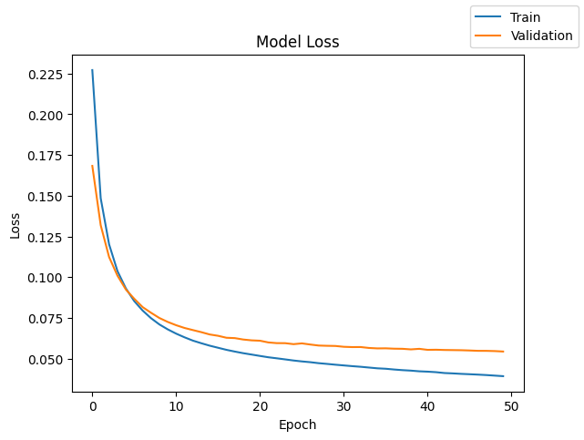

```python
plot(history,'loss')
```

```python
model_1_train_perf = model_performance_classification(model_1,X_train,y_train)
model_1_train_perf
```

```
500/500 ━━━━━━━━━━━━━━━━━━━━ 0s 691us/step
```

|  | Accuracy | Recall | Precision | F1 Score |
| --- | --- | --- | --- | --- |
| 0 | 0.992125 | 0.933294 | 0.990983 | 0.960108 |

```python
model_1_val_perf = model_performance_classification(model_1,X_val,y_val)
model_1_val_perf
```

```
125/125 ━━━━━━━━━━━━━━━━━━━━ 0s 875us/step
```

|  | Accuracy | Recall | Precision | F1 Score |
| --- | --- | --- | --- | --- |
| 0 | 0.99 | 0.920509 | 0.982384 | 0.949054 |

```python
y_train_pred_1 = model_1.predict(X_train)
y_val_pred_1 = model_1.predict(X_val)
```

```
500/500 ━━━━━━━━━━━━━━━━━━━━ 0s 758us/step
125/125 ━━━━━━━━━━━━━━━━━━━━ 0s 714us/step
```

```python
print("Classification Report - Train data Model_1", end="\n\n")
cr_train_model_1 = classification_report(y_train,y_train_pred_1 > 0.35)
print(cr_train_model_1)
```

```
Classification Report - Train data Model_1

              precision    recall  f1-score   support

         0.0       0.99      1.00      1.00     15112
         1.0       0.98      0.89      0.93       888

    accuracy                           0.99     16000
   macro avg       0.99      0.94      0.96     16000
weighted avg       0.99      0.99      0.99     16000
```

```python
print("Classification Report - Validation data Model_1", end="\n\n")
cr_val_model_1 = classification_report(y_val,y_val_pred_1 > 0.35)
print(cr_val_model_1)
```

```
Classification Report - Validation data Model_1

              precision    recall  f1-score   support

         0.0       0.99      1.00      1.00      3778
         1.0       0.97      0.86      0.91       222

    accuracy                           0.99      4000
   macro avg       0.98      0.93      0.95      4000
weighted avg       0.99      0.99      0.99      4000
```

### Model 1 — Observations and Insights

**Architecture**

**Final Model Performance**

[output not shown]

**Classification Report — Failure class (Class 1) only:**

[output not shown]

**Comparison with Model 0 (Validation)**

[output not shown]

## Model 2

To introduce Regularization in our model, let's set the dropout to 50% after adding the first hidden layer. This step will randomly drop 50% of the neurons before proceeding to the next layer, reducing overfitting.

```python
# clears the current Keras session, resetting all layers and models previously created, freeing up memory and resources.
tf.keras.backend.clear_session()
```

```python
#Initializing the neural network
from tensorflow.keras.layers import Dropout
model_2 = Sequential()
model_2.add(Dense(64,activation="relu",input_dim=X_train.shape[1]))  # Complete the code to define the number of neurons and activation function
model_2.add(Dropout(0.5)) # Complete the code to define the dropout rate
model_2.add(Dense(32,activation = "relu")) # Complete the code to define the number of neurons and activation function
model_2.add(Dense(16,activation = "relu")) # Complete the code to define the number of neurons and activation function
model_2.add(Dense(1,activation="sigmoid")) # Complete the code to define the number of neurons in the output layer
```

```python
model_2.summary()
```

```
Model: "sequential"
```

```
┏━━━━━━━━━━━━━━━━━━━━━━━━━━━━━━━━━┳━━━━━━━━━━━━━━━━━━━━━━━━┳━━━━━━━━━━━━━━━┓
┃ Layer (type)                    ┃ Output Shape           ┃       Param # ┃
┡━━━━━━━━━━━━━━━━━━━━━━━━━━━━━━━━━╇━━━━━━━━━━━━━━━━━━━━━━━━╇━━━━━━━━━━━━━━━┩
│ dense (Dense)                   │ (None, 64)             │         2,624 │
├─────────────────────────────────┼────────────────────────┼───────────────┤
│ dropout (Dropout)               │ (None, 64)             │             0 │
├─────────────────────────────────┼────────────────────────┼───────────────┤
│ dense_1 (Dense)                 │ (None, 32)             │         2,080 │
├─────────────────────────────────┼────────────────────────┼───────────────┤
│ dense_2 (Dense)                 │ (None, 16)             │           528 │
├─────────────────────────────────┼────────────────────────┼───────────────┤
│ dense_3 (Dense)                 │ (None, 1)              │            17 │
└─────────────────────────────────┴────────────────────────┴───────────────┘
```

```
 Total params: 5,249 (20.50 KB)
```

```
 Trainable params: 5,249 (20.50 KB)
```

```
 Non-trainable params: 0 (0.00 B)
```

```python
optimizer = tf.keras.optimizers.SGD()   # defining SGD as the optimizer to be used
# model_2.compile(loss='binary_crossentropy', optimizer=optimizer, metrics = ['accuracy']) ## Uncomment this line in case the metric of choice is Accuracy
# model_2.compile(loss='binary_crossentropy', optimizer=optimizer, metrics = ['Precision']) ## Uncomment this line in case the metric of choice is Precision
model_2.compile(loss='binary_crossentropy', optimizer=optimizer, metrics = ['Recall']) ## Uncomment this line in case the metric of choice is Recall
# model_2.compile(loss='binary_crossentropy', optimizer=optimizer, metrics = ['f1_score']) ## Uncomment this line in case the metric of choice is F1 Score
```

```python
start = time.time()
history = model_2.fit(X_train, y_train, validation_data=(X_val,y_val) , batch_size=batch_size, epochs=epochs)
end=time.time()
```

```
500/500 ━━━━━━━━━━━━━━━━━━━━ 1s 2ms/step - Recall: 0.0282 - loss: 0.2507 - val_Recall: 0.0676 - val_loss: 0.1633
500/500 ━━━━━━━━━━━━━━━━━━━━ 1s 1ms/step - Recall: 0.1318 - loss: 0.1731 - val_Recall: 0.4189 - val_loss: 0.1321
500/500 ━━━━━━━━━━━━━━━━━━━━ 1s 1ms/step - Recall: 0.2534 - loss: 0.1532 - val_Recall: 0.5766 - val_loss: 0.1156
500/500 ━━━━━━━━━━━━━━━━━━━━ 1s 1ms/step - Recall: 0.3502 - loss: 0.1386 - val_Recall: 0.6216 - val_loss: 0.1033
500/500 ━━━━━━━━━━━━━━━━━━━━ 1s 1ms/step - Recall: 0.3953 - loss: 0.1299 - val_Recall: 0.6306 - val_loss: 0.0954
500/500 ━━━━━━━━━━━━━━━━━━━━ 1s 1ms/step - Recall: 0.4392 - loss: 0.1211 - val_Recall: 0.6802 - val_loss: 0.0897
500/500 ━━━━━━━━━━━━━━━━━━━━ 1s 1ms/step - Recall: 0.4685 - loss: 0.1148 - val_Recall: 0.7207 - val_loss: 0.0850
500/500 ━━━━━━━━━━━━━━━━━━━━ 1s 1ms/step - Recall: 0.5079 - loss: 0.1082 - val_Recall: 0.7342 - val_loss: 0.0808
500/500 ━━━━━━━━━━━━━━━━━━━━ 1s 1ms/step - Recall: 0.5405 - loss: 0.1019 - val_Recall: 0.7342 - val_loss: 0.0780
500/500 ━━━━━━━━━━━━━━━━━━━━ 1s 1ms/step - Recall: 0.5574 - loss: 0.0993 - val_Recall: 0.7523 - val_loss: 0.0756
500/500 ━━━━━━━━━━━━━━━━━━━━ 1s 1ms/step - Recall: 0.5777 - loss: 0.0948 - val_Recall: 0.7658 - val_loss: 0.0729
500/500 ━━━━━━━━━━━━━━━━━━━━ 1s 1ms/step - Recall: 0.5878 - loss: 0.0934 - val_Recall: 0.7748 - val_loss: 0.0718
500/500 ━━━━━━━━━━━━━━━━━━━━ 1s 1ms/step - Recall: 0.6250 - loss: 0.0898 - val_Recall: 0.7613 - val_loss: 0.0695
500/500 ━━━━━━━━━━━━━━━━━━━━ 1s 1ms/step - Recall: 0.5980 - loss: 0.0920 - val_Recall: 0.7658 - val_loss: 0.0686
500/500 ━━━━━━━━━━━━━━━━━━━━ 1s 1ms/step - Recall: 0.6498 - loss: 0.0854 - val_Recall: 0.7748 - val_loss: 0.0675
500/500 ━━━━━━━━━━━━━━━━━━━━ 1s 1ms/step - Recall: 0.6295 - loss: 0.0864 - val_Recall: 0.7883 - val_loss: 0.0660
500/500 ━━━━━━━━━━━━━━━━━━━━ 1s 1ms/step - Recall: 0.6486 - loss: 0.0831 - val_Recall: 0.8018 - val_loss: 0.0650
500/500 ━━━━━━━━━━━━━━━━━━━━ 1s 1ms/step - Recall: 0.6734 - loss: 0.0803 - val_Recall: 0.7658 - val_loss: 0.0641
500/500 ━━━━━━━━━━━━━━━━━━━━ 1s 1ms/step - Recall: 0.6757 - loss: 0.0783 - val_Recall: 0.7928 - val_loss: 0.0629
500/500 ━━━━━━━━━━━━━━━━━━━━ 1s 1ms/step - Recall: 0.6926 - loss: 0.0750 - val_Recall: 0.8018 - val_loss: 0.0619
500/500 ━━━━━━━━━━━━━━━━━━━━ 1s 1ms/step - Recall: 0.6959 - loss: 0.0756 - val_Recall: 0.8063 - val_loss: 0.0612
500/500 ━━━━━━━━━━━━━━━━━━━━ 1s 1ms/step - Recall: 0.6982 - loss: 0.0747 - val_Recall: 0.8018 - val_loss: 0.0604
500/500 ━━━━━━━━━━━━━━━━━━━━ 1s 1ms/step - Recall: 0.7005 - loss: 0.0716 - val_Recall: 0.8108 - val_loss: 0.0598
500/500 ━━━━━━━━━━━━━━━━━━━━ 1s 1ms/step - Recall: 0.7117 - loss: 0.0709 - val_Recall: 0.8198 - val_loss: 0.0600
500/500 ━━━━━━━━━━━━━━━━━━━━ 1s 1ms/step - Recall: 0.7241 - loss: 0.0698 - val_Recall: 0.7838 - val_loss: 0.0600
500/500 ━━━━━━━━━━━━━━━━━━━━ 1s 1ms/step - Recall: 0.6892 - loss: 0.0730 - val_Recall: 0.7928 - val_loss: 0.0591
500/500 ━━━━━━━━━━━━━━━━━━━━ 1s 1ms/step - Recall: 0.7286 - loss: 0.0688 - val_Recall: 0.8243 - val_loss: 0.0585
500/500 ━━━━━━━━━━━━━━━━━━━━ 1s 1ms/step - Recall: 0.7331 - loss: 0.0680 - val_Recall: 0.8288 - val_loss: 0.0581
500/500 ━━━━━━━━━━━━━━━━━━━━ 1s 1ms/step - Recall: 0.7410 - loss: 0.0663 - val_Recall: 0.8243 - val_loss: 0.0581
500/500 ━━━━━━━━━━━━━━━━━━━━ 1s 1ms/step - Recall: 0.7399 - loss: 0.0656 - val_Recall: 0.8333 - val_loss: 0.0574
500/500 ━━━━━━━━━━━━━━━━━━━━ 1s 1ms/step - Recall: 0.7444 - loss: 0.0664 - val_Recall: 0.8243 - val_loss: 0.0576
500/500 ━━━━━━━━━━━━━━━━━━━━ 1s 1ms/step - Recall: 0.7275 - loss: 0.0681 - val_Recall: 0.8333 - val_loss: 0.0570
500/500 ━━━━━━━━━━━━━━━━━━━━ 1s 1ms/step - Recall: 0.7421 - loss: 0.0659 - val_Recall: 0.8243 - val_loss: 0.0571
500/500 ━━━━━━━━━━━━━━━━━━━━ 1s 1ms/step - Recall: 0.7421 - loss: 0.0646 - val_Recall: 0.8288 - val_loss: 0.0565
500/500 ━━━━━━━━━━━━━━━━━━━━ 1s 1ms/step - Recall: 0.7444 - loss: 0.0639 - val_Recall: 0.8288 - val_loss: 0.0571
500/500 ━━━━━━━━━━━━━━━━━━━━ 1s 1ms/step - Recall: 0.7455 - loss: 0.0648 - val_Recall: 0.8288 - val_loss: 0.0567
500/500 ━━━━━━━━━━━━━━━━━━━━ 1s 1ms/step - Recall: 0.7624 - loss: 0.0635 - val_Recall: 0.8243 - val_loss: 0.0565
500/500 ━━━━━━━━━━━━━━━━━━━━ 1s 1ms/step - Recall: 0.7601 - loss: 0.0628 - val_Recall: 0.8333 - val_loss: 0.0566
500/500 ━━━━━━━━━━━━━━━━━━━━ 1s 1ms/step - Recall: 0.7489 - loss: 0.0623 - val_Recall: 0.8288 - val_loss: 0.0562
500/500 ━━━━━━━━━━━━━━━━━━━━ 1s 2ms/step - Recall: 0.7601 - loss: 0.0603 - val_Recall: 0.8288 - val_loss: 0.0560
500/500 ━━━━━━━━━━━━━━━━━━━━ 1s 1ms/step - Recall: 0.7714 - loss: 0.0600 - val_Recall: 0.8378 - val_loss: 0.0562
500/500 ━━━━━━━━━━━━━━━━━━━━ 1s 1ms/step - Recall: 0.7714 - loss: 0.0605 - val_Recall: 0.8378 - val_loss: 0.0555
500/500 ━━━━━━━━━━━━━━━━━━━━ 1s 1ms/step - Recall: 0.7759 - loss: 0.0613 - val_Recall: 0.8423 - val_loss: 0.0554
500/500 ━━━━━━━━━━━━━━━━━━━━ 1s 1ms/step - Recall: 0.7736 - loss: 0.0572 - val_Recall: 0.8378 - val_loss: 0.0558
500/500 ━━━━━━━━━━━━━━━━━━━━ 1s 2ms/step - Recall: 0.7658 - loss: 0.0604 - val_Recall: 0.8423 - val_loss: 0.0559
500/500 ━━━━━━━━━━━━━━━━━━━━ 1s 1ms/step - Recall: 0.7894 - loss: 0.0584 - val_Recall: 0.8423 - val_loss: 0.0552
500/500 ━━━━━━━━━━━━━━━━━━━━ 1s 2ms/step - Recall: 0.7748 - loss: 0.0582 - val_Recall: 0.8378 - val_loss: 0.0555
500/500 ━━━━━━━━━━━━━━━━━━━━ 1s 1ms/step - Recall: 0.7804 - loss: 0.0577 - val_Recall: 0.8423 - val_loss: 0.0561
500/500 ━━━━━━━━━━━━━━━━━━━━ 1s 1ms/step - Recall: 0.7894 - loss: 0.0570 - val_Recall: 0.8423 - val_loss: 0.0556
500/500 ━━━━━━━━━━━━━━━━━━━━ 1s 1ms/step - Recall: 0.7669 - loss: 0.0585 - val_Recall: 0.8423 - val_loss: 0.0557
```